# PREDICCIÓN DEL VOLUMEN DE VENTAS E IMPACTO DE LAS RESEÑAS

#### 5.3.1.1 MULTICOLINEALIDAD: PROPUESTA 1

Tomamos las variables vistas anteriormente para la Propuesta 1. Veamos ahora un resumen de las variables que mejor correlan con la variable objetivo:

```r
#Función que devuelve un dataframe con los valores de correlación ordenados de mayor a menor
Corr_Vars <- function(datos) {
    Pares <- combn(names(datos), 2, simplify = FALSE)
    df <- data.frame(Variable1 = rep(0, length(Pares)),
                     Variable2 = rep(0, length(Pares)),
                     Correlacion = rep(0, length(Pares)))
    for (i in 1:length(Pares)) {
        df[i, 1] <- Pares[[i]][1]
        df[i, 2] <- Pares[[i]][2]
        df[i, 3] <- round(cor(datos[, Pares[[i]][1]], datos[, Pares[[i]][2]]),3)
    }
    Corr_VarsDF <- df
    Corr_VarsDF <- Corr_VarsDF[order(abs(Corr_VarsDF$Correlacion), decreasing = TRUE),]
    row.names(Corr_VarsDF) <- 1:length(Pares)
    Corr_VarsDF <- Corr_VarsDF[which(Corr_VarsDF$Variable1 == "Volumen"), ]
    names(Corr_VarsDF) <- c('Variable 1','Variable 2','Correlación')
    return(Corr_VarsDF)
}
#Mostramos tabla resumen
Corr_Vars(EPA[Propuesta1]) %>% kbl() %>% kable_classic(full_width=FALSE,html_font='Cambria')
```

|  | Variable 1 | Variable 2 | Correlación |
| --- | --- | --- | --- |
| 1 | Volumen | Star4 | 0.727 |
| 5 | Volumen | SerPos | 0.617 |
| 10 | Volumen | Star2 | 0.450 |
| 12 | Volumen | SerFra | 0.390 |
| 17 | Volumen | Peso | -0.320 |
| 27 | Volumen | Reco | 0.261 |
| 29 | Volumen | Prof | 0.241 |
| 31 | Volumen | Ancho | -0.219 |
| 37 | Volumen | Precio | -0.183 |
| 38 | Volumen | PC | -0.179 |
| 43 | Volumen | Netbook | -0.159 |
| 45 | Volumen | Alto | -0.151 |
| 48 | Volumen | Beneficio | 0.141 |
| 59 | Volumen | Laptop | -0.106 |
| 84 | Volumen | Smartphone | -0.058 |

Se define el proceso para calcular el modelo y se obtienen los resultados tomando las 10 mejores variables.

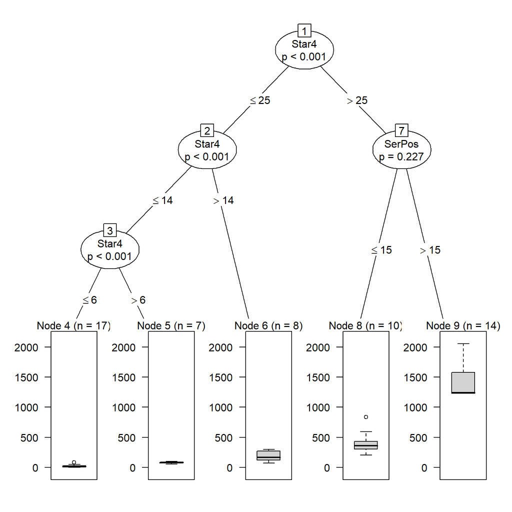

Figure 33: Árbol de Decisión. Propuesta 1.

```r
#Variables seleccionadas Propuesta 1
Prop1_Sel <- c('Volumen','Star4','SerPos','Star2','SerFra','Peso','Reco','Prof','Ancho','Precio','PC')
# define el proceso para calcular los parámetros. En este caso se usa un cross validation de 5 particiones
set.seed(100)
Process <- trainControl(method = "repeatedcv", repeats = 1, number=5)
#Entrenamos un modelo de árbol
CTree1.Fit <- train(Volumen ~ ., data =EPA_Training[Prop1_Sel], method = "ctree",
                       trControl=Process,tuneLength = 10)
#Mostramos árbol de decisión
plot(CTree1.Fit$finalModel)
```

```r
#Métricas
CTree1.Fit$results
```

```
##    mincriterion     RMSE  Rsquared      MAE    RMSESD RsquaredSD    MAESD
## 1     0.0100000 296.8223 0.7386429 181.1885 121.95399  0.1689437 73.58413
## 2     0.1188889 296.8223 0.7386429 181.1885 121.95399  0.1689437 73.58413
## 3     0.2277778 296.8223 0.7386429 181.1885 121.95399  0.1689437 73.58413
## 4     0.3366667 296.8223 0.7386429 181.1885 121.95399  0.1689437 73.58413
## 5     0.4455556 296.8223 0.7386429 181.1885 121.95399  0.1689437 73.58413
## 6     0.5544444 296.8223 0.7386429 181.1885 121.95399  0.1689437 73.58413
## 7     0.6633333 296.8223 0.7386429 181.1885 121.95399  0.1689437 73.58413
## 8     0.7722222 319.4452 0.7173820 193.1838  86.24384  0.1379460 57.67881
## 9     0.8811111 319.4452 0.7173820 193.1838  86.24384  0.1379460 57.67881
## 10    0.9900000 319.4452 0.7173820 193.1838  86.24384  0.1379460 57.67881
```

```r
#Importancia variables
CTree1.Importance <- varImp(CTree1.Fit)
plot(CTree1.Importance)
```

Fijémonos que el tipo de producto no juega ningún papel en el árbol de decisión.

#### 5.3.1.2 MULTICOLINEALIDAD: PROPUESTA 2

Tomamos las variables vistas anteriormente para la Propuesta 2. Veamos ahora un resumen de las variables que mejor correlan con la variable objetivo:

```r
#Mostramos tabla resumen
Corr_Vars(EPA[Propuesta2]) %>% kbl() %>% kable_classic(full_width=FALSE,html_font='Cambria')
```

|  | Variable 1 | Variable 2 | Correlación |
| --- | --- | --- | --- |
| 2 | Volumen | NRes | 0.761 |
| 3 | Volumen | Star_lm | 0.729 |
| 6 | Volumen | SerPos | 0.617 |
| 12 | Volumen | SerFra | 0.390 |
| 18 | Volumen | Peso | -0.320 |
| 28 | Volumen | Reco | 0.261 |
| 30 | Volumen | Prof | 0.241 |
| 33 | Volumen | Ancho | -0.219 |
| 38 | Volumen | Precio | -0.183 |
| 39 | Volumen | PC | -0.179 |
| 45 | Volumen | Netbook | -0.159 |
| 46 | Volumen | Alto | -0.151 |
| 50 | Volumen | Beneficio | 0.141 |
| 63 | Volumen | Laptop | -0.106 |
| 87 | Volumen | Smartphone | -0.058 |

Se define el proceso para calcular el modelo y se obtienen los resultados tomando las 10 mejores variables.

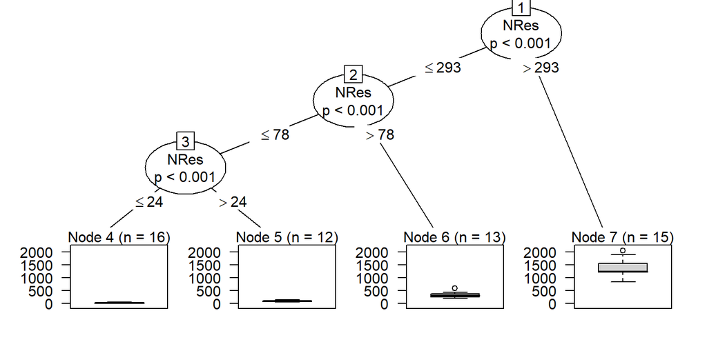

Figure 34: Árbol de Decisión. Propuesta 2.

```r
#Variables seleccionadas Propuesta 2
Prop2_Sel <- c('Volumen','NRes','Star_lm','SerPos','SerFra','Peso','Reco','Prof','Ancho','Precio','PC')
# define el proceso para calcular los parámetros. En este caso se usa un cross validation de 5 particiones
set.seed(100)
#Entrenamos un modelo de árbol
CTree2.Fit <- train(Volumen ~ ., data =EPA_Training[Prop2_Sel], method = "ctree",
                       trControl=Process,tuneLength = 10)
#Mostramos árbol de decisión
plot(CTree2.Fit$finalModel)
```

```r
#Métricas
CTree2.Fit$results
```

```
##    mincriterion     RMSE  Rsquared      MAE   RMSESD RsquaredSD    MAESD
## 1     0.0100000 227.8217 0.8387043 135.3616 83.46204  0.1395247 54.53726
## 2     0.1188889 227.8217 0.8387043 135.3616 83.46204  0.1395247 54.53726
## 3     0.2277778 227.8217 0.8387043 135.3616 83.46204  0.1395247 54.53726
## 4     0.3366667 227.8217 0.8387043 135.3616 83.46204  0.1395247 54.53726
## 5     0.4455556 227.8217 0.8387043 135.3616 83.46204  0.1395247 54.53726
## 6     0.5544444 227.8217 0.8387043 135.3616 83.46204  0.1395247 54.53726
## 7     0.6633333 227.8217 0.8387043 135.3616 83.46204  0.1395247 54.53726
## 8     0.7722222 227.8217 0.8387043 135.3616 83.46204  0.1395247 54.53726
## 9     0.8811111 227.8217 0.8387043 135.3616 83.46204  0.1395247 54.53726
## 10    0.9900000 227.8217 0.8387043 135.3616 83.46204  0.1395247 54.53726
```

```r
#Importancia variables
CTree2.Importance <- varImp(CTree2.Fit)
plot(CTree2.Importance)
```

Fijémonos que el tipo de producto no juega ningún papel en el árbol de decisión.

## 5.4 APLICACIÓN DE LOS ALGORITMOS

Llegados a este punto ya estamos preparados para crear nuestros primeros modelos. A continuación se obtienen los modelos predictivos utilizando cada una de las propuestas.

### 5.4.1 RANDOM FOREST

En este apartado consideraremos el algoritmo Random Forest.

#### 5.4.1.1 OPTIMIZACIÓN DE PARÁMETROS

Para el algoritmo *RandomForest*, tenemos un único parámetro a optimizar: *mtry*. A continuación se define el proceso de optimización de dicho parámetro.

- PROPUESTA 1

```r
#Se calculan las métricas a través del proceso definido por la función train() (parámetros escogidos automáticamente)
set.seed(100)
RF1.Time <- system.time(RF1.Fit <- train(Volumen ~ ., data =EPA_Training[Prop1_Sel], method = "rf",
                                  trControl=Process, tuneLength = 10))
```

- PROPUESTA 2

```r
#Se calculan las métricas a través del proceso definido por la función train() (parámetros escogidos automáticamente)
set.seed(100)
RF2.Time <- system.time(RF2.Fit <- train(Volumen ~ ., data =EPA_Training[Prop2_Sel], method = "rf",
                                  trControl=Process, tuneLength = 10))
```

#### 5.4.1.2 FIABILIDAD DE LAS PREDICCIONES

Se muestra el valor de las métricas. Prestamos especial atención al coeficiente de determinación (Rsquared)

- PROPUESTA 1

```r
#Métricas
RF1.Metrics <- RF1.Fit$results[which.max(RF1.Fit$results[,'Rsquared']),-1] %>%
                  cbind(data.frame('Tiempo'=RF1.Time['elapsed']))
RF1.Fit$results
```

```
##   mtry     RMSE  Rsquared       MAE    RMSESD RsquaredSD    MAESD
## 1    2 236.0940 0.8645580 147.39454 101.18129 0.17147398 65.32797
## 2    3 208.1534 0.8797454 122.11103 110.75729 0.15597131 64.85259
## 3    4 184.9198 0.9038270 103.06094  98.66829 0.11628851 54.12840
## 4    5 171.9581 0.9111579  96.32742 104.91678 0.10608581 56.78073
## 5    6 165.7767 0.9154480  88.74460 104.24099 0.09552133 50.64664
## 6    7 161.8122 0.9204471  86.75024 100.12432 0.07948886 47.76982
## 7    8 161.2352 0.9208218  85.56775  97.56898 0.07936210 43.34683
## 8    9 163.7206 0.9186767  85.05715 100.51443 0.07870868 42.95072
## 9   10 171.8104 0.9138846  87.48250  99.57740 0.07732643 39.68955
```

- PROPUESTA 2

```r
#Métricas
RF2.Metrics <- RF2.Fit$results[which.max(RF2.Fit$results[,'Rsquared']),-1] %>%
                  cbind(data.frame('Tiempo'=RF2.Time['elapsed']))
RF2.Fit$results
```

```
##   mtry     RMSE  Rsquared       MAE   RMSESD RsquaredSD    MAESD
## 1    2 187.2803 0.9256325 110.82470 82.60834 0.06454425 39.28914
## 2    3 145.1805 0.9492927  80.98498 78.70892 0.04209271 32.81327
## 3    4 130.9442 0.9589333  72.44096 67.82982 0.02731512 27.53206
## 4    5 127.6267 0.9584108  69.26013 70.07342 0.02773487 30.44529
## 5    6 124.9604 0.9608742  65.14783 63.52149 0.02447339 29.59486
## 6    7 125.2812 0.9610933  63.67862 66.42757 0.02478652 31.33148
## 7    8 125.8827 0.9612216  64.82620 66.10330 0.02403722 32.78257
## 8    9 127.6575 0.9600528  65.08296 68.17861 0.02687364 34.14372
## 9   10 125.3115 0.9615735  64.79833 68.83911 0.02740719 34.14564
```

#### 5.4.1.3 IMPORTANCIA DE LAS VARIABLES

Veamos las variables de mayor peso en la regresión

- PROPUESTA 1

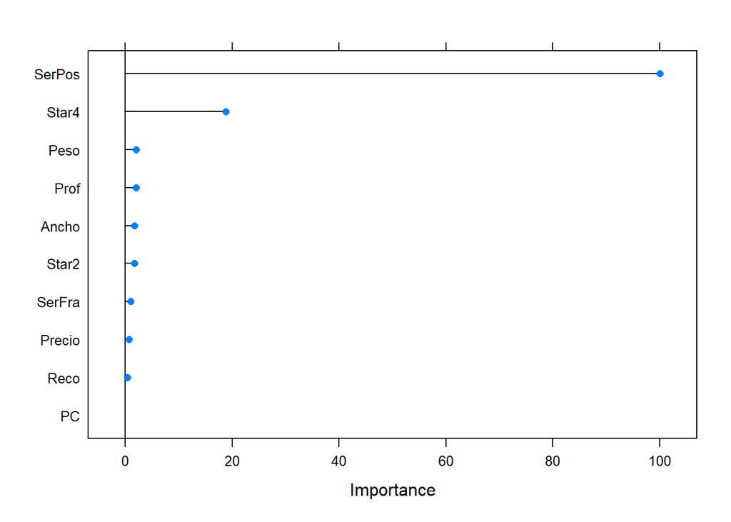

```r
#Importancia variables
RF1.Importance <- varImp(RF1.Fit)
plot(RF1.Importance)
```

* PROPUESTA 2

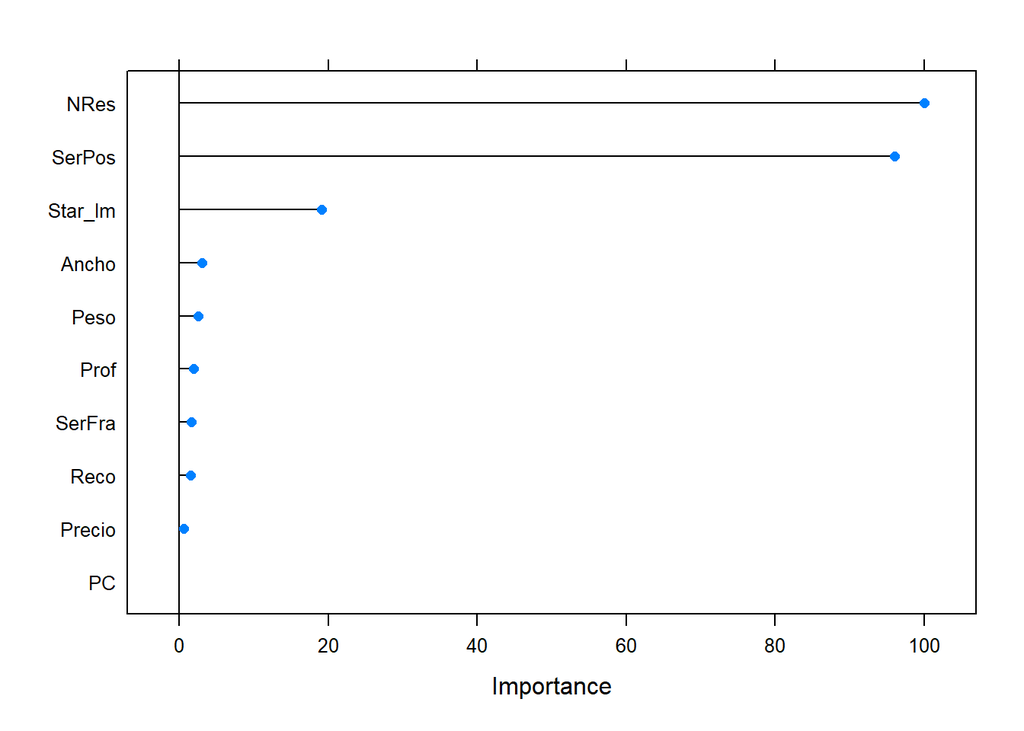

```r
#Importancia variables
RF2.Importance <- varImp(RF2.Fit)
plot(RF2.Importance)
```

### 5.4.2 SUPPORT VECTOR MACHINE. LINEAL.

En este apartado consideraremos el algoritmo Support Vector Machine Lineal.

#### 5.4.2.1 OPTIMIZACIÓN DE PARÁMETROS

Para el algoritmo escogido, tenemos un único parámetro a optimizar: *C*. A continuación se define el proceso de optimización de dicho parámetro.

- PROPUESTA 1

```r
#Se calculan las métricas a través del proceso definido por la función train() (parámetros escogidos automáticamente)
set.seed(100)
SVML1.Time <- system.time(SVML1.Fit <- train(Volumen ~ ., data =EPA_Training[Prop1_Sel], method = "svmLinear",
                                  trControl=Process, tuneLength = 10))
```

- PROPUESTA 2

```r
#Se calculan las métricas a través del proceso definido por la función train() (parámetros escogidos automáticamente)
set.seed(100)
SVML2.Time <- system.time(SVML2.Fit <- train(Volumen ~ ., data =EPA_Training[Prop2_Sel], method = "svmLinear",
                                  trControl=Process, tuneLength = 10))
```

#### 5.4.2.2 FIABILIDAD DE LAS PREDICCIONES

Se muestra el valor de las métricas. Prestamos especial atención al coeficiente de determinación (Rsquared)

- PROPUESTA 1

```r
#Métricas
SVML1.Metrics <- SVML1.Fit$results[which.max(SVML1.Fit$results[,'Rsquared']),-1] %>%
                  cbind(data.frame('Tiempo'=SVML1.Time['elapsed']))
SVML1.Fit$results
```

```
##   C     RMSE  Rsquared      MAE   RMSESD RsquaredSD    MAESD
## 1 1 361.2074 0.8355785 173.5802 203.6024   0.121223 95.49342
```

- PROPUESTA 2

```r
#Métricas
SVML2.Metrics <- SVML2.Fit$results[which.max(SVML2.Fit$results[,'Rsquared']),-1] %>%
                  cbind(data.frame('Tiempo'=SVML2.Time['elapsed']))
SVML2.Fit$results
```

```
##   C     RMSE  Rsquared     MAE   RMSESD RsquaredSD    MAESD
## 1 1 630.0647 0.8142186 251.121 801.9351  0.1268314 239.8749
```

#### 5.4.2.3 IMPORTANCIA DE LAS VARIABLES

Veamos las variables de mayor peso en la regresión

- PROPUESTA 1

```r
#Importancia variables
SVML1.Importance <- varImp(SVML1.Fit)
plot(SVML1.Importance)
```

* PROPUESTA 2

```r
#Importancia variables
SVML2.Importance <- varImp(SVML2.Fit)
plot(SVML2.Importance)
```

### 5.4.3 SUPPORT VECTOR MACHINE. RADIAL.

En este apartado consideraremos el algoritmo Support Vector Machine Radial.

#### 5.4.3.1 OPTIMIZACIÓN DE PARÁMETROS

Para el algoritmo escogido, tenemos dos parámetros a optimizar: *C* y *sigma*. A continuación se define el proceso de optimización de dichos parámetros.

- PROPUESTA 1

```r
#Se calculan las métricas a través del proceso definido por la función train() (parámetros escogidos automáticamente)
set.seed(100)
SVMR1.Time <- system.time(SVMR1.Fit <- train(Volumen ~ ., data =EPA_Training[Prop1_Sel], method = "svmRadial",
                                  trControl=Process, tuneLength = 10))
```

- PROPUESTA 2

```r
#Se calculan las métricas a través del proceso definido por la función train() (parámetros escogidos automáticamente)
set.seed(100)
SVMR2.Time <- system.time(SVMR2.Fit <- train(Volumen ~ ., data =EPA_Training[Prop2_Sel], method = "svmRadial",
                                  trControl=Process, tuneLength = 10))
```

#### 5.4.3.2 FIABILIDAD DE LAS PREDICCIONES

Se muestra el valor de las métricas. Prestamos especial atención al coeficiente de determinación (Rsquared)

- PROPUESTA 1

```r
#Métricas
SVMR1.Metrics <- SVMR1.Fit$results[which.max(SVMR1.Fit$results[,'Rsquared']),-c(1,2)] %>%
                  cbind(data.frame('Tiempo'=SVMR1.Time['elapsed']))
SVMR1.Fit$results
```

```
##        sigma      C     RMSE  Rsquared      MAE   RMSESD RsquaredSD    MAESD
## 1  0.2988516   0.25 462.9912 0.5020978 262.0253 112.7335 0.07351997 81.81165
## 2  0.2988516   0.50 445.4449 0.5201214 243.9419 112.4303 0.09149394 87.25640
## 3  0.2988516   1.00 425.9487 0.5398546 247.0752 105.3306 0.11141972 87.98504
## 4  0.2988516   2.00 409.8668 0.5478798 266.8869 106.0731 0.16008820 91.60192
## 5  0.2988516   4.00 408.2618 0.5462021 269.3743 105.1754 0.16333964 88.84368
## 6  0.2988516   8.00 408.2374 0.5462729 269.2803 105.0378 0.16295690 88.69725
## 7  0.2988516  16.00 408.2374 0.5462729 269.2803 105.0378 0.16295690 88.69725
## 8  0.2988516  32.00 408.2374 0.5462729 269.2803 105.0378 0.16295690 88.69725
## 9  0.2988516  64.00 408.2374 0.5462729 269.2803 105.0378 0.16295690 88.69725
## 10 0.2988516 128.00 408.2374 0.5462729 269.2803 105.0378 0.16295690 88.69725
```

- PROPUESTA 2

```r
#Métricas
SVMR2.Metrics <- SVMR2.Fit$results[which.max(SVMR2.Fit$results[,'Rsquared']),-c(1,2)] %>%
                  cbind(data.frame('Tiempo'=SVMR2.Time['elapsed']))
SVMR2.Fit$results
```

```
##        sigma      C     RMSE  Rsquared      MAE    RMSESD RsquaredSD    MAESD
## 1  0.2839006   0.25 454.5291 0.5170028 253.2731 110.92091 0.07889528 81.45884
## 2  0.2839006   0.50 438.3912 0.5369301 237.3392 110.80802 0.09411219 86.23618
## 3  0.2839006   1.00 412.9066 0.5721764 238.4500 102.98090 0.10722076 81.17977
## 4  0.2839006   2.00 394.7815 0.5920785 249.4623  99.69029 0.13247730 81.94799
## 5  0.2839006   4.00 393.1587 0.5933757 249.8063  99.04485 0.13471320 81.40177
## 6  0.2839006   8.00 393.1587 0.5933757 249.8063  99.04485 0.13471320 81.40177
## 7  0.2839006  16.00 393.1587 0.5933757 249.8063  99.04485 0.13471320 81.40177
## 8  0.2839006  32.00 393.1587 0.5933757 249.8063  99.04485 0.13471320 81.40177
## 9  0.2839006  64.00 393.1587 0.5933757 249.8063  99.04485 0.13471320 81.40177
## 10 0.2839006 128.00 393.1587 0.5933757 249.8063  99.04485 0.13471320 81.40177
```

#### 5.4.3.3 IMPORTANCIA DE LAS VARIABLES

Veamos las variables de mayor peso en la regresión

- PROPUESTA 1

```r
#Importancia variables
SVMR1.Importance <- varImp(SVMR1.Fit)
plot(SVMR1.Importance)
```

* PROPUESTA 2

```r
#Importancia variables
SVMR2.Importance <- varImp(SVMR2.Fit)
plot(SVMR2.Importance)
```

### 5.4.4 GRADIENT BOOSTING.

En este apartado consideraremos el algoritmo Gradient Boosting.

#### 5.4.4.1 OPTIMIZACIÓN DE PARÁMETROS

Para el algoritmo escogido tenemos varios parámetros a optimizar:

- *ntrees*
- *interaction.depth*
- *shrinkage*
- *n.minobsinnode*

A continuación se define el proceso de optimización de los parámetros.

- PROPUESTA 1

```r
#Se calculan las métricas a través del proceso definido por la función train() (parámetros escogidos automáticamente)
set.seed(100)
GB1.Time <- system.time(capture.output(GB1.Fit <- train(Volumen ~ ., data =EPA_Training[Prop1_Sel], method = "gbm",
                                  trControl=Process, tuneLength = 10)))
```

- PROPUESTA 2

```r
#Se calculan las métricas a través del proceso definido por la función train() (parámetros escogidos automáticamente)
set.seed(100)
GB2.Time <- system.time(capture.output(GB2.Fit <- train(Volumen ~ ., data =EPA_Training[Prop2_Sel], method = "gbm",
                                  trControl=Process, tuneLength = 10)))
```

#### 5.4.4.2 FIABILIDAD DE LAS PREDICCIONES

Se muestra el valor de las métricas. Prestamos especial atención al coeficiente de determinación (Rsquared)

- PROPUESTA 1

```r
#Métricas
GB1.Metrics <- GB1.Fit$results[which.max(GB1.Fit$results[,'Rsquared']),-seq(1,4)] %>%
                  cbind(data.frame('Tiempo'=GB1.Time['elapsed']))
GB1.Fit$results[which.max(GB1.Fit$results[,'Rsquared']),]
```

```
##    shrinkage interaction.depth n.minobsinnode n.trees     RMSE  Rsquared
## 20       0.1                 2             10     500 272.4025 0.7931437
##         MAE   RMSESD RsquaredSD    MAESD
## 20 191.0647 84.80854  0.1044885 60.80526
```

- PROPUESTA 2

```r
#Métricas
GB2.Metrics <- GB2.Fit$results[which.max(GB2.Fit$results[,'Rsquared']),-seq(1,4)] %>%
                  cbind(data.frame('Tiempo'=GB2.Time['elapsed']))
GB2.Fit$results[which.max(GB2.Fit$results[,'Rsquared']),]
```

```
##    shrinkage interaction.depth n.minobsinnode n.trees     RMSE  Rsquared
## 20       0.1                 2             10     500 282.9091 0.7873405
##         MAE   RMSESD RsquaredSD    MAESD
## 20 196.8773 61.00957 0.08058343 57.51756
```

#### 5.4.4.3 IMPORTANCIA DE LAS VARIABLES

Veamos las variables de mayor peso en la regresión

- PROPUESTA 1

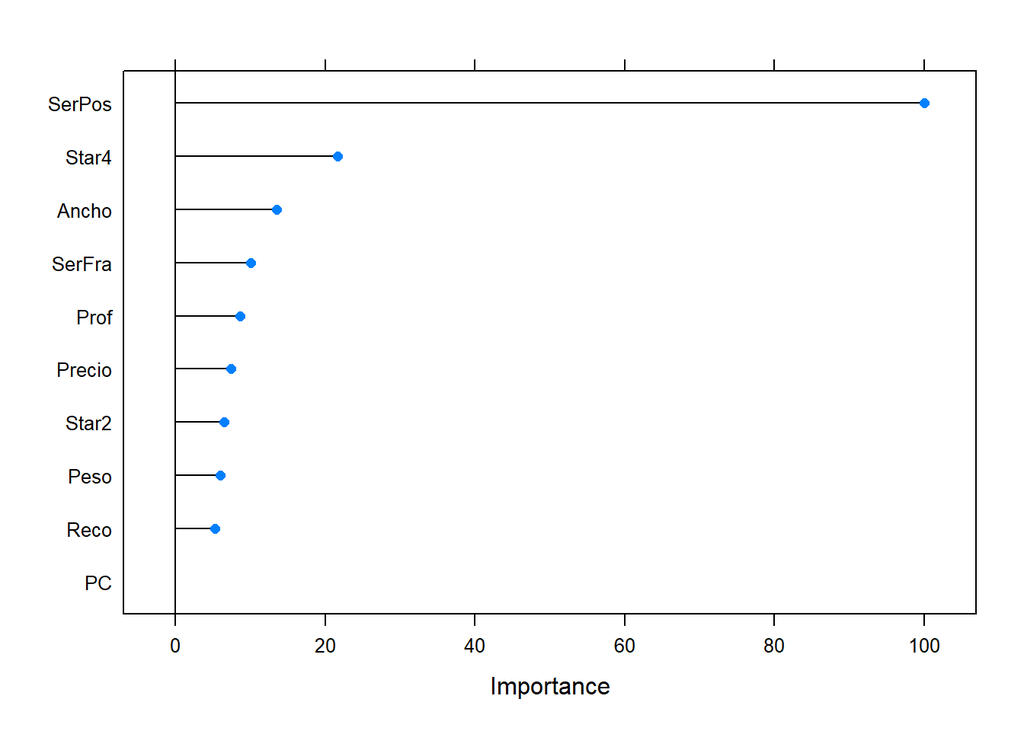

```r
#Importancia variables
GB1.Importance <- varImp(GB1.Fit)
plot(GB1.Importance)
```

* PROPUESTA 2

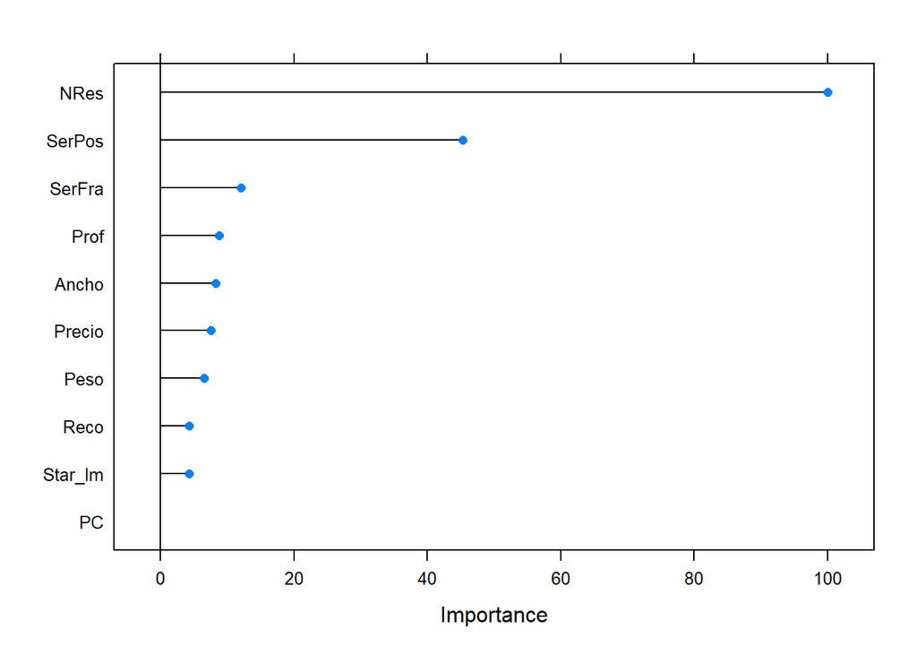

```r
#Importancia variables
GB2.Importance <- varImp(GB2.Fit)
plot(GB2.Importance)
```

### 5.4.5 K-NEAREST NEIGHBOR

En este apartado consideraremos el algoritmo K-Nearest Neighbor.

#### 5.4.5.1 OPTIMIZACIÓN DE PARÁMETROS

Para el algoritmo escogido tenemos varios parámetros a optimizar: * *kmax* * *distance* * *kernel*

A continuación se define el proceso de optimización de los parámetros.

- PROPUESTA 1

```r
#Se calculan las métricas a través del proceso definido por la función train() (parámetros escogidos automáticamente)
set.seed(100)
KNN1.Time <- system.time(KNN1.Fit <- train(Volumen ~ ., data =EPA_Training[Prop1_Sel], method = "kknn",
                                  trControl=Process, tuneLength = 10))
```

- PROPUESTA 2

```r
#Se calculan las métricas a través del proceso definido por la función train() (parámetros escogidos automáticamente)
set.seed(100)
KNN2.Time <- system.time(KNN2.Fit <- train(Volumen ~ ., data =EPA_Training[Prop2_Sel], method = "kknn",
                                  trControl=Process, tuneLength = 10))
```

#### 5.4.5.2 FIABILIDAD DE LAS PREDICCIONES

Se muestra el valor de las métricas. Prestamos especial atención al coeficiente de determinación (Rsquared)

- PROPUESTA 1

```r
#Métricas
KNN1.Metrics <- KNN1.Fit$results[which.max(KNN1.Fit$results[,'Rsquared']),-seq(1,3)] %>%
                  cbind(data.frame('Tiempo'=KNN1.Time['elapsed']))
KNN1.Fit$results
```

```
##    kmax distance  kernel     RMSE Rsquared      MAE  RMSESD RsquaredSD    MAESD
## 1     5        2 optimal 282.8761  0.80234 163.5847 163.818  0.1708443 97.87851
## 2     7        2 optimal 282.8761  0.80234 163.5847 163.818  0.1708443 97.87851
## 3     9        2 optimal 282.8761  0.80234 163.5847 163.818  0.1708443 97.87851
## 4    11        2 optimal 282.8761  0.80234 163.5847 163.818  0.1708443 97.87851
## 5    13        2 optimal 282.8761  0.80234 163.5847 163.818  0.1708443 97.87851
## 6    15        2 optimal 282.8761  0.80234 163.5847 163.818  0.1708443 97.87851
## 7    17        2 optimal 282.8761  0.80234 163.5847 163.818  0.1708443 97.87851
## 8    19        2 optimal 282.8761  0.80234 163.5847 163.818  0.1708443 97.87851
## 9    21        2 optimal 282.8761  0.80234 163.5847 163.818  0.1708443 97.87851
## 10   23        2 optimal 282.8761  0.80234 163.5847 163.818  0.1708443 97.87851
```

- PROPUESTA 2

```r
#Métricas
KNN2.Metrics <- KNN2.Fit$results[which.max(KNN2.Fit$results[,'Rsquared']),-seq(1,3)] %>%
                  cbind(data.frame('Tiempo'=KNN2.Time['elapsed']))
KNN2.Fit$results
```

```
##    kmax distance  kernel     RMSE  Rsquared      MAE   RMSESD RsquaredSD
## 1     5        2 optimal 239.8598 0.8573087 147.2614 169.9374  0.1664957
## 2     7        2 optimal 239.8598 0.8573087 147.2614 169.9374  0.1664957
## 3     9        2 optimal 239.8598 0.8573087 147.2614 169.9374  0.1664957
## 4    11        2 optimal 239.8598 0.8573087 147.2614 169.9374  0.1664957
## 5    13        2 optimal 239.8598 0.8573087 147.2614 169.9374  0.1664957
## 6    15        2 optimal 239.8598 0.8573087 147.2614 169.9374  0.1664957
## 7    17        2 optimal 239.8598 0.8573087 147.2614 169.9374  0.1664957
## 8    19        2 optimal 239.8598 0.8573087 147.2614 169.9374  0.1664957
## 9    21        2 optimal 239.8598 0.8573087 147.2614 169.9374  0.1664957
## 10   23        2 optimal 239.8598 0.8573087 147.2614 169.9374  0.1664957
##       MAESD
## 1  100.4926
## 2  100.4926
## 3  100.4926
## 4  100.4926
## 5  100.4926
## 6  100.4926
## 7  100.4926
## 8  100.4926
## 9  100.4926
## 10 100.4926
```

#### 5.4.5.3 IMPORTANCIA DE LAS VARIABLES

Veamos las variables de mayor peso en la regresión

- PROPUESTA 1

```r
#Importancia variables
KNN1.Importance <- varImp(KNN1.Fit)
plot(KNN1.Importance)
```

* PROPUESTA 2

```r
#Importancia variables
KNN2.Importance <- varImp(KNN2.Fit)
plot(KNN2.Importance)
```

# 6 EVALUACIÓN Y REPORTE DE LOS RESULTADOS

Ahora ya hemos visto los resultados de todos los modelos propuestos y estamos en disposición de analizar cuál de ellos va a proporcionar mejores resultados.

## 6.1 SELECCIÓN DEL MODELO Y JUSTIFICACIÓN

En el ajuste de cada uno de los modelos se han calculado las métricas sobre su rendimiento. En la siguiente tabla se muestra un resumen de tanto las métricas como el tiempo de ejecución de cada modelo.

```r
#Vectores con nombres
Modelos <- c('RF1','SVML1','SVMR1','GB1','KNN1','RF2','SVML2','SVMR2','GB2','KNN2')
Metricas <- c('Rsquared','MAE','RMSE','Tiempo','RsquaredSD','MAESD','RMSESD')
Metricas_Norm <- c('RMSE01','Rsquared01','MAE01','RMSESD01','RsquaredSD01','MAESD01','Tiempo01')
#Creamos dataframe con las métricas de todos los modelos
Metric_Summary <- rbind(RF1.Metrics,SVML1.Metrics,SVMR1.Metrics,GB1.Metrics,KNN1.Metrics,
                         RF2.Metrics,SVML2.Metrics,SVMR2.Metrics,GB2.Metrics,KNN2.Metrics)
#Creamos dataframe con valores 0-1 (se normalizan valores) donde 0 es mala calidad y 1 buena.
Metric_Summary01 <- preProcess(Metric_Summary, method=c("range")) %>% predict(Metric_Summary)
colnames(Metric_Summary01) <- Metricas_Norm
Metric_Summary01['Rsquared01'] <- 1-Metric_Summary01$Rsquared01 #en el caso de R2 se debe invertir la escala
#Se unen dataframes
Metric_Summary_HM <-  cbind(Metric_Summary,Metric_Summary01,data.frame('Modelo'=Modelos))
#Se redondean valores de las métricas
Metric_Summary_HM[c(2,5)] <- round(Metric_Summary_HM[c(2,5)],4)
Metric_Summary_HM[c(1,3,4,6)] <- round(Metric_Summary_HM[c(1,3,4,6)],0)
Metric_Summary_HM[7] <- round(Metric_Summary_HM[7],2)
#Se pasa tabla de forma ancha a larga
Metric_Summary_HM <- Metric_Summary_HM %>% gather(Metrica, value, RMSE:Tiempo) %>% cbind(Metric_Summary01 %>% gather(Metrica01, Norm, RMSE01:Tiempo01))
#Se transforman a variables factor
Metric_Summary_HM$Metrica <- factor(Metric_Summary_HM$Metrica,levels=Metricas)
Metric_Summary_HM$Modelo <- factor(Metric_Summary_HM$Modelo,levels=Modelos)
```

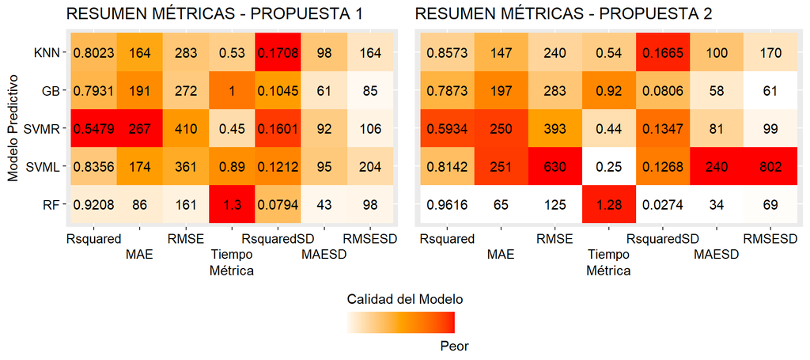

Figure 35: Resumen de las Métricas resultantes para cada uno de los modelos analizados.

```r
sum1<-filter(Metric_Summary_HM, grepl('1', Modelo)) %>%
  ggplot(aes(x=Metrica,y=Modelo,fill=Norm))+geom_bin2d()+
  geom_text(aes(label = value))+
  scale_fill_gradient2(midpoint=0.5, low="white", mid="orange",high="red",
                       space ="Lab",breaks=c(0,1),labels = c('Mejor','Peor'),
                       name = "Calidad del Modelo")+
  guides(fill = guide_colorbar(title.position = "top"))+
  theme(axis.text.x = element_text(color='black',size=10,angle=0),
        legend.text=element_text(size=11),
        axis.text.y = element_text(color='black',size=10,angle=0))+
  scale_x_discrete(name ="Métrica",guide=guide_axis(n.dodge=2))+
  scale_y_discrete(name ="Modelo Predictivo",labels=c('RF','SVML','SVMR','GB','KNN'))+
  ggtitle('RESUMEN MÉTRICAS - PROPUESTA 1')

sum2<-filter(Metric_Summary_HM, grepl('2', Modelo)) %>%
  ggplot(aes(x=Metrica,y=Modelo,fill=Norm))+geom_bin2d()+
  geom_text(aes(label = value))+
    scale_fill_gradient2(midpoint=0.5, low="white", mid="orange",high="red",
                         space ="Lab",breaks=c(0,1),labels = c('Mejor','Peor'),
                         name = "Calidad del Modelo")+
  guides(fill = guide_colorbar(title.position = "top"))+
  theme(axis.text.x = element_text(color='black',size=10,angle=0),
        legend.text=element_text(size=11),
        axis.text.y=element_blank(),axis.title.y=element_blank(),axis.ticks.y=element_blank())+
  scale_x_discrete(name ="Métrica",guide=guide_axis(n.dodge=2))+
  ggtitle('RESUMEN MÉTRICAS - PROPUESTA 2')

ggarrange(sum1,sum2,nrow=1,ncol=2,common.legend = TRUE, legend='bottom')
```

Se observa que la propuesta 2 ofrece mejores resultados en general. En cuanto a los algoritmos, *Random Forest* destaca sobre los demás y con diferencia. Por lo tanto, el modelo resultante del algoritmo *Random Forest* junto a la segunda propuesta en la selección de *features* da los mejores resultados y se convierte en el modelo escogido para realizar las predicciones finales.

Antes de abarcar esta tarea, se deben ajustar los parámetros con precisión sobre el subgrupo test así como analizar el error asociado.

## 6.2 AJUSTE DEL MODELO SELECCIONADO

Ajustamos el modelo definitivo, en este caso el random forest utilizando la segunda propuesta de features.

### 6.2.1 OPTIMIZACIÓN DE PARÁMETROS

Para el algoritmo *RandomForest*, tenemos un único parámetro a optimizar: *mtry*. A continuación se define el proceso de optimización de dicho parámetro. Esta vez damos una lista de valores sobre los que optimizar. Esta lista se basa en los resultados obtenidos anteriormente.

```r
# Definimos un Grid con los valores entre los que optimizar
ModSel.Grid <- expand.grid(mtry = seq(5,15))
#Se calculan las métricas a través del proceso definido por la función train() (parámetros escogidos automáticamente)
set.seed(100)
ModSel.Time <- system.time(ModSel.Fit <- train(Volumen ~ ., data =EPA_Training[Prop2_Sel], method = "rf",
                                  trControl=Process, tuneGrid=ModSel.Grid))
```

### 6.2.2 FIABILIDAD DE LAS PREDICCIONES

Se muestra el valor de las métricas. Prestamos especial atención al coeficiente de determinación (Rsquared)

```r
#Métricas
ModSel.Metrics <- ModSel.Fit$results[which.max(ModSel.Fit$results[,'Rsquared']),-1] %>%
                  cbind(data.frame('Tiempo'=ModSel.Time['elapsed']))
ModSel.Fit$results[which.max(ModSel.Fit$results[,'Rsquared']),]
```

```
##   mtry     RMSE  Rsquared      MAE   RMSESD RsquaredSD    MAESD
## 4    8 121.2892 0.9632885 62.81594 65.22758 0.02491483 32.28804
```

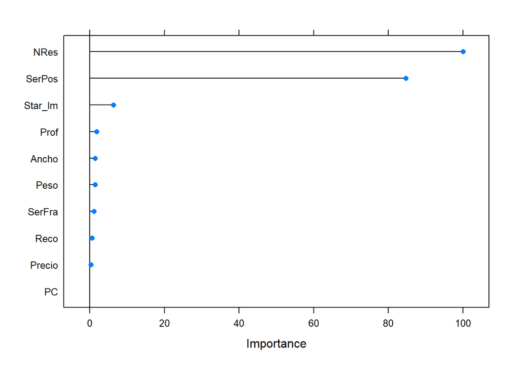

```r
#Importancia variables
ModSel.Importance <- varImp(ModSel.Fit)
plot(ModSel.Importance)
```

### 6.2.3 ANÁLISIS DEL ERROR

```r
#Predicciones
ModSel.Predict <- predict(ModSel.Fit,EPA_Test[Prop2_Sel])
#Error Absoluto
ModSel.AbsolutError <- abs(EPA_Test['Volumen']-ModSel.Predict)
#Error Relativo
ModSel.RelativeError <- ModSel.AbsolutError/EPA_Test['Volumen']
#Dataframe con los datos del error y las variables más relevantes para el análisis
Error_DF <- errors_df <- as.data.frame(cbind(EPA_Test['Volumen'], ModSel.Predict, ModSel.AbsolutError,
                         ModSel.RelativeError,EPA_Test['Tipo'],EPA_Test['NRes'],EPA_Test['SerPos']))
colnames(Error_DF) <- c('Real','Predicho','ErrorAbsoluto','ErrorRelativo','Tipo','NRes','SerPos')
```

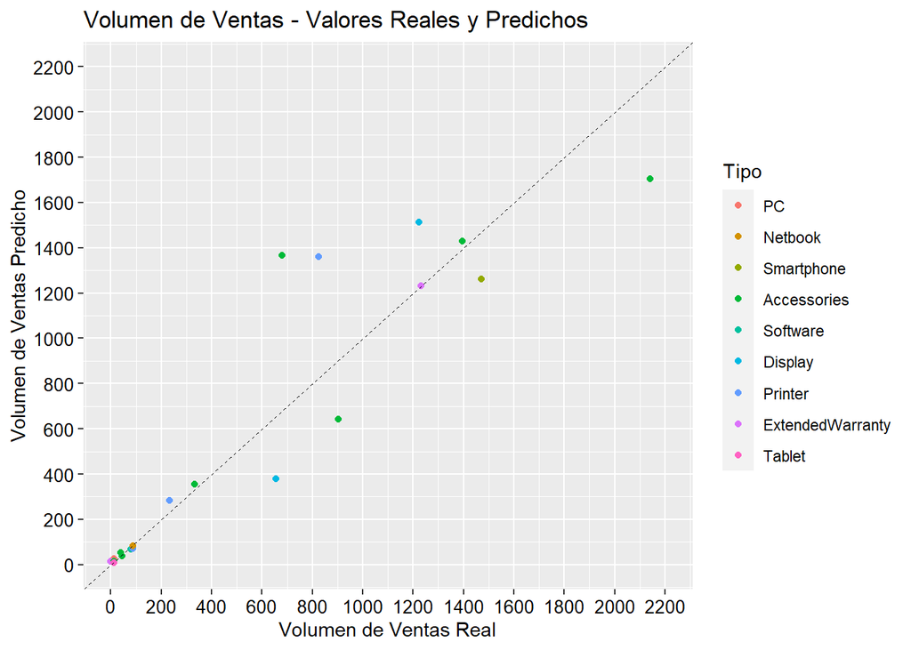

Figure 36: Error asociado a las predicciones. Valores reales contra predichos.

```r
#Scatter Plot Volumen Real - Volumen Predicho
EPA_VolumenRealPredicho <- Error_DF %>% ggplot(aes(x=Real,y=Predicho,color=Tipo))+geom_point()+
  ggtitle('Volumen de Ventas - Valores Reales y Predichos')+
  theme(axis.text.y = element_text(color='black',size=10,angle=0),
        axis.text.x = element_text(color='black',size=10,angle=0))+
  scale_x_continuous(name ="Volumen de Ventas Real",limits=c(0,2200),breaks=seq(0,2200,200))+
  scale_y_continuous(name ="Volumen de Ventas Predicho",limits=c(0,2200),breaks=seq(0,2200,200))+
  geom_abline(intercept = 0, slope = 1, color="black",linetype="dashed", size=0.3)
EPA_VolumenRealPredicho
```

El gráfico de la figura 36 nos da las primeras pistas sobre la distribución del error. Las discrepancias más significativas se dan para valores altos del volumen de ventas.

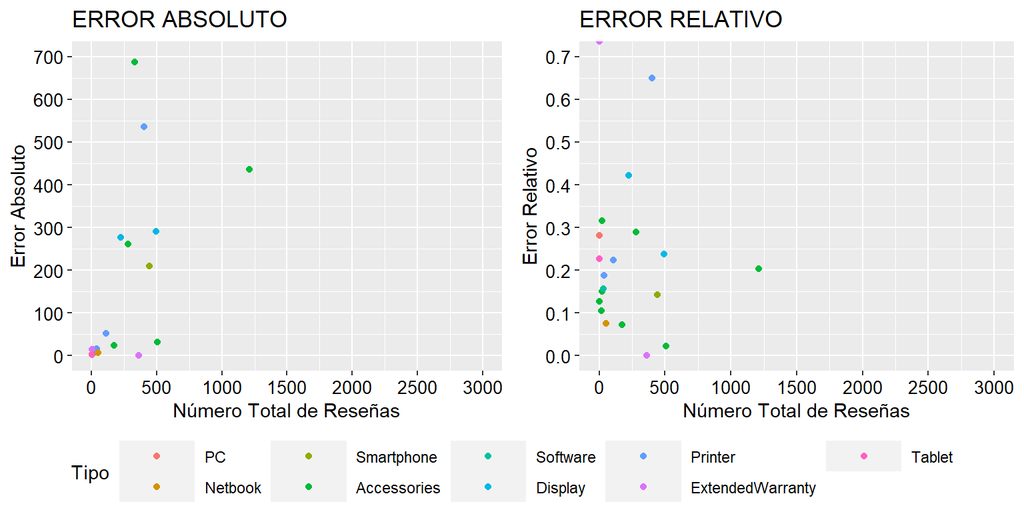

Figure 37: Error asociado a las predicciones en función de la variable predictora más relevante.

```r
#Scatter Plot Nº Reseñas - Error Absoluto
EPA_NResErrorA <- Error_DF %>% ggplot(aes(x=NRes,y=ErrorAbsoluto,color=Tipo))+geom_point()+
  ggtitle('ERROR ABSOLUTO')+
  theme(axis.text.y = element_text(color='black',size=10,angle=0),
        axis.text.x = element_text(color='black',size=10,angle=0),
        legend.key.width = unit(1.5, 'cm'))+
  scale_x_continuous(name ="Número Total de Reseñas",limits=c(0,3000),breaks=seq(0,3000,500))+
  scale_y_continuous(name ="Error Absoluto",limits=c(0,700),breaks=seq(0,700,100))
#Scatter Plot Nº Reseñas - Error Relativo
EPA_NResErrorR <- Error_DF %>% ggplot(aes(x=NRes,y=ErrorRelativo,color=Tipo))+geom_point()+
  ggtitle('ERROR RELATIVO')+
  theme(axis.text.y = element_text(color='black',size=10,angle=0),
        axis.text.x = element_text(color='black',size=10,angle=0),
        legend.key.width = unit(1.5, 'cm'))+
  scale_x_continuous(name ="Número Total de Reseñas",limits=c(0,3000),breaks=seq(0,3000,500))+
    scale_y_continuous(name ="Error Relativo",limits=c(0,0.7),breaks=seq(0,0.7,0.1))
ggarrange(EPA_NResErrorA,EPA_NResErrorR,nrow=1,ncol=2, legend='bottom',common.legend = TRUE)
```

El error absoluto aumenta cuanto mayor es el número de reseñas que, a su vez, coincide con mayores valores del volumen de ventas. Se deberá tener especial precaución con los productos con mayor número de reseñas ya que el volumen de ventas real puede variar significativamente. Sin embargo, el error relativo no muestra una tendencia clara y toma valores muy dispares.

En los gráficos 36 y 37 se diferencia las predicciones según el tipo de producto. De nuevo queda en evidencia que el tipo de producto no juega un papel relevante y el error no se ve influenciado por este.

## 6.3 PREDICCIÓN DE RESULTADOS

Para predecir los resultados finales necesitamos tener las mismas variables que hemos creado en el conjunto de datos de entramiento. El primer paso será crearlos en el conjunto objetivo:

```r
#Creamos variable reseña media ponderada para el conjunto de datos objetivo
NPA$Star_lm <- lm_coef[2]*NPA$Star4+lm_coef[3]*NPA$Star2
#Se calcula la reseña media
NPA$SerFra <- NPA %>% with(SerPos/(SerPos+SerNeg))
NPA$SerFra[is.na(NPA$SerFra)] <- 0
```

Obtenemos el modelo

```r
#Se calculan las métricas a través del proceso definido por la función train() (parámetros escogidos automáticamente)
set.seed(100)
Model.Time <- system.time(Model.Fit <- train(Volumen ~ ., data =EPA[Prop2_Sel], method = "rf",
                                  trControl=Process, tuneGrid=ModSel.Grid))
#Métricas
Model.Metrics <- Model.Fit$results[which.max(Model.Fit$results[,'Rsquared']),-1] %>%
                  cbind(data.frame('Tiempo'=Model.Time['elapsed']))
Model.Fit$results[which.max(Model.Fit$results[,'Rsquared']),]
```

```
##   mtry     RMSE  Rsquared      MAE  RMSESD RsquaredSD    MAESD
## 7   11 152.9758 0.9395644 79.18531 57.7058 0.04287366 27.58073
```

Realizamos las predicciones sobre el conjunto objetivo

```r
#Predicciones
NPA$Volumen <- predict(Model.Fit,NPA[Prop2_Sel])
```

Se muestra la distribución de las predicciones

##### RESUMEN GRÁFICO

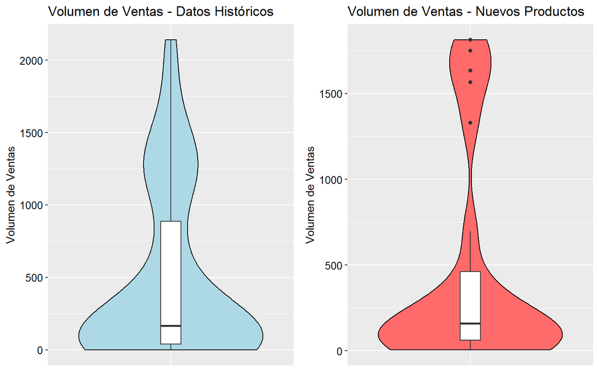

Figure 38: Distribución de la variable referente al volumen de ventas.

```r
#Violin plot Beneficio EPA
NPA_Volumen <- ggplot(NPA,aes(x=factor(0),y=Volumen))+
  geom_violin(color="black",fill='indianred1')+
  geom_boxplot(width=0.1)+
  ggtitle('Volumen de Ventas - Nuevos Productos')+
  theme(axis.text.x=element_blank(),
        axis.ticks.x=element_blank(),
        axis.title.x=element_blank(),
        axis.text.y = element_text(color='black',size=10,angle=0))+
  scale_y_continuous(name ="Volumen de Ventas")

ggarrange(EPA_Volumen2,NPA_Volumen,nrow=1,ncol=2)
```

##### TABLA RESUMEN

```r
#Mostramos tabla resumen
NPA$Volumen <- round(NPA$Volumen,0)
NPA[c('Tipo','ID','Volumen')] %>% kbl() %>% kable_classic(full_width=FALSE,html_font='Cambria')
```

| Tipo | ID | Volumen |
| --- | --- | --- |
| PC | 171 | 383 |
| PC | 172 | 191 |
| Laptop | 173 | 190 |
| Laptop | 175 | 36 |
| Laptop | 176 | 9 |
| Netbook | 178 | 85 |
| Netbook | 180 | 1566 |
| Netbook | 181 | 143 |
| Netbook | 183 | 15 |
| Tablet | 186 | 1329 |
| Tablet | 187 | 1813 |
| Smartphone | 193 | 367 |
| Smartphone | 194 | 695 |
| Smartphone | 195 | 101 |
| Smartphone | 196 | 225 |
| GameConsole | 199 | 1634 |
| Display | 201 | 12 |
| Accessories | 301 | 71 |
| Accessories | 302 | 80 |
| Software | 303 | 117 |
| Printer | 304 | 176 |
| PrinterSupplies | 305 | 17 |
| ExtendedWarranty | 306 | 5 |
| GameConsole | 307 | 1750 |

A continuación se muestra el volumen de ventas de ambos conjuntos de datos en función de las variables más relevantes del análisis.

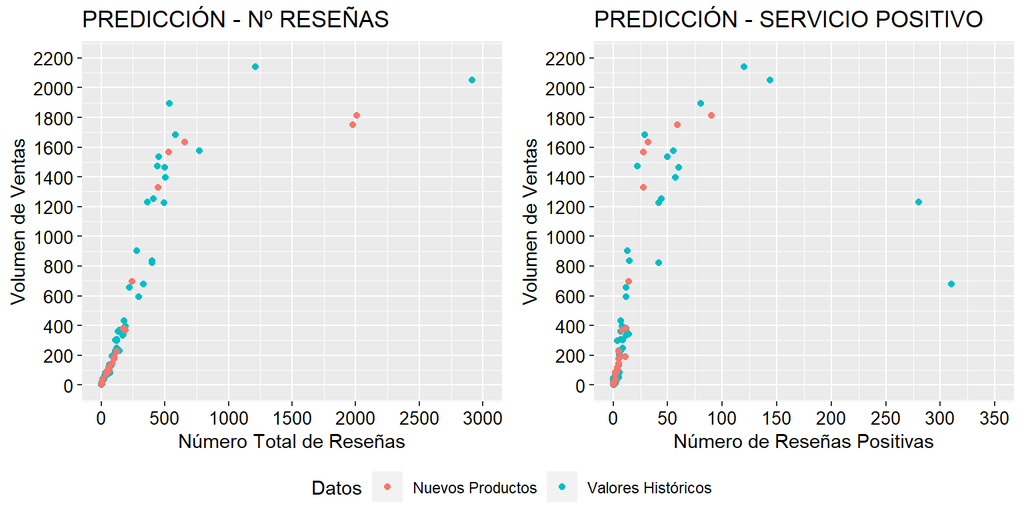

Figure 39: Predicciones del volumen de ventas en función de las variables más relevantes.

```r
EPA$Datos <- 'Valores Históricos'
NPA$Datos <- 'Nuevos Productos'
Pre_NRes <- rbind(EPA[c('NRes','Volumen','Datos')],NPA[c('NRes','Volumen','Datos')]) %>%
  ggplot(aes(x=NRes,y=Volumen,color=Datos))+geom_point()+
  ggtitle('PREDICCIÓN - Nº RESEÑAS')+
  theme(axis.text.y = element_text(color='black',size=10,angle=0),
        axis.text.x = element_text(color='black',size=10,angle=0))+
  scale_x_continuous(name ="Número Total de Reseñas",limits=c(0,3000),breaks=seq(0,3000,500))+
  scale_y_continuous(name ="Volumen de Ventas",limits=c(0,2200),breaks=seq(0,2200,200))

Pre_SerPos <- rbind(EPA[c('SerPos','Volumen','Datos')],NPA[c('SerPos','Volumen','Datos')]) %>%
  ggplot(aes(x=SerPos,y=Volumen,color=Datos))+geom_point()+
  ggtitle('PREDICCIÓN - SERVICIO POSITIVO')+
  theme(axis.text.y = element_text(color='black',size=10,angle=0),
        axis.text.x = element_text(color='black',size=10,angle=0))+
  scale_x_continuous(name ="Número de Reseñas Positivas",limits=c(0,350),breaks=seq(0,350,50))+
  scale_y_continuous(name ="Volumen de Ventas",limits=c(0,2200),breaks=seq(0,2200,200))

ggarrange(Pre_NRes,Pre_SerPos,nrow=1,ncol=2, legend='bottom',common.legend = TRUE)
```

Las predicciones son muy fieles a los datos históricos considerando el número total de reseñas así como el número de reseñas referentes al servicio, con la excepción de los dos puntos asociados a las muestras de mayor volumen de ventas. Sin embargo, estos dos puntos que se alejan de la tendencia general, no pertenecen a los tipos de interés, sino que se trata de una tablet y una videconsola (veáse la figura 40).

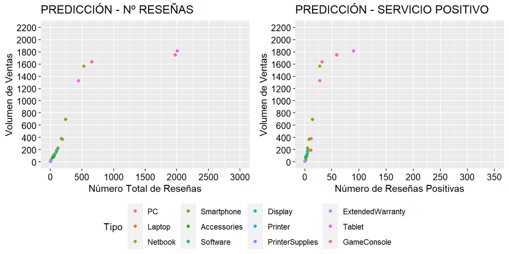

Figure 40: Predicciones del volumen de ventas en función del total de reseñas.

```r
Pre_NResTipo <- ggplot(NPA,aes(x=NRes,y=Volumen,color=Tipo))+geom_point()+
  ggtitle('PREDICCIÓN - Nº RESEÑAS')+
  theme(axis.text.y = element_text(color='black',size=10,angle=0),
        axis.text.x = element_text(color='black',size=10,angle=0))+
  scale_x_continuous(name ="Número Total de Reseñas",limits=c(0,3000),breaks=seq(0,3000,500))+
  scale_y_continuous(name ="Volumen de Ventas",limits=c(0,2200),breaks=seq(0,2200,200))

Pre_SerPosTipo <- ggplot(NPA,aes(x=SerPos,y=Volumen,color=Tipo))+geom_point()+
  ggtitle('PREDICCIÓN - SERVICIO POSITIVO')+
  theme(axis.text.y = element_text(color='black',size=10,angle=0),
        axis.text.x = element_text(color='black',size=10,angle=0))+
  scale_x_continuous(name ="Número de Reseñas Positivas",limits=c(0,350),breaks=seq(0,350,50))+
  scale_y_continuous(name ="Volumen de Ventas",limits=c(0,2200),breaks=seq(0,2200,200))

ggarrange(Pre_NResTipo,Pre_SerPosTipo,nrow=1,ncol=2, legend='bottom',common.legend = TRUE)
```

## 6.4 RESUMEN DE RESULTADOS Y CONCLUSIONES

El modelo definitivo nos proporciona una buena precisión y es fiel a los datos históricos con alguna excepción. El modelo no es capaz de predecir con precisión los puntos de mayor volumen de ventas. La razón recae en la falta de datos históricos cercanos a estos para algunas de las variables predictoras. En consecuencia, la precisión podría verse afectada para estos productos.

Estos puntos se pueden identificar fácilmente en la figura 39 izquierda. Cuando mostramos los resultados en función del total de reseñas, aparecen dos puntos aislados (en rojo) alejados de todo dato histórico. Afortunadamente, estos productos no coinciden con los productos objetivo, sino que se tratan de una tablet y una videconsola (veáse la figura 40).

A pesar de ello, para otras variables predictoras como el número de reseñas positivas del servicio, sí tenemos datos cercanos. Se puede decir que la predicción si es fiel a la tendencia marcada por algunas variables predictoras (veáse la figura 39 derecha).

Recordemos ahora las preguntas iniciales que se nos plantean:

- **Predecir las ventas de los siguientes productos: Ordenadores, portátiles, netbooks y teléfonos móviles.**

Se ha comprobado que el tipo de producto no juega ningún papel en el volumen de ventas. Esto significa que el modelo de predicción es independiente del tipo de producto y las variables predictoras son comunes para todos ellos.

A continuación se muestra una tabla resumen de las predicciones de los productos de interés:

```r
#Mostramos tabla resumen
NPA[c('Tipo','ID','Volumen')] %>%
  filter(Tipo=='PC' | Tipo=='Smartphone' | Tipo=='Netbook' | Tipo=='Laptop') %>%
  kbl() %>% kable_classic(full_width=FALSE,html_font='Cambria')
```

|  | Tipo | ID | Volumen |
| --- | --- | --- | --- |
| 1 | PC | 171 | 383 |
| 2 | PC | 172 | 191 |
| 3 | Laptop | 173 | 190 |
| 4 | Laptop | 175 | 36 |
| 5 | Laptop | 176 | 9 |
| 6 | Netbook | 178 | 85 |
| 7 | Netbook | 180 | 1566 |
| 8 | Netbook | 181 | 143 |
| 9 | Netbook | 183 | 15 |
| 12 | Smartphone | 193 | 367 |
| 13 | Smartphone | 194 | 695 |
| 14 | Smartphone | 195 | 101 |
| 15 | Smartphone | 196 | 225 |

Se debe destacar el número de ventas de cuatro productos en el siguiente orden: Netbook (180), Smartphone (194), PC (171) y Smartphone (193). El resto de valores son más discretos.

- **Evaluar el impacto en ventas que tienen las reseñas de los clientes sobre los productos y servicios.**

Durante el análisis exploratorio se visualizó cómo afectan las reseñas al volumen de ventas.

La cantidad de reseñas de 5 estrellas afecta directamente al volumen de ventas, correlando de forma perfecta y siendo esta directamente proporcional al número de reseñas. En la figura 16 puede verse en detalle que la relación entre las ventas y las reseñas es de 4:1, por lo que cada reseña de máxima puntuación te garantiza 4 ventas.

A medida que bajamos el grado de satisfacción de la reseña, se pierde correlación con el volumen de ventas, pero la correlación sigue siendo más que aceptable para reseñas de 4 y hasta 3 estrellas.

Si consideramos el valor medio de las reseñas, el gráfico de la figura 27 muestra una tendencia muy clara. El valor medio de las reseñas tiene cierta influencia en el volumen de ventas. Sin embargo, existe una condición para que se dé esta dependencia: el número de reseñas. Una buena valoración media no es relevante si no viene acompañada por una cantidad significativa de reseñas.

Por ejemplo, un producto con buena valoración media pero pocas reseñas no da confianza al consumidor. Este caso sería el de todos los puntos mostrados en color rojo en el gráfico de la figura 27.

A pesar de todo, se puede concluir que el número de reseñas para cada grado de valoración (así como el) aporta muchísimas más información que el valor medio.

Para las reseñas del servicio ocurre algo parecido. Vemos que el ejemplo anterior sigue aplicando para las reseñas del servicio según se muestra en la figura 28 (los puntos en rojo siguen dominando para bajos volúmenes de venta). Sin embargo, a diferencia de las reseñas del producto, las muestras con una cantidad de reseñas moderada o alta no siguen un patrón tan claro.